# Assignment1

2025-09-04

What is the impact of movie duration on movie rating, controlling for the movie’s release year?

Introduction Research Motivation and Research Question Movie rating is a key determinant of a film’s ability to attract viewers (Austin, 1980) and has been shown to influence performance measures such as box office revenues (Moon et al., 2010). While multiple factors affect ratings, movie duration is an especially relevant but underexplored dimension. Research indicates that episode length can significantly shape viewer ratings (Danaher et al., 2011). However, limited work has addressed whether similar effects exist for movies. This study addresses this gap by examining the research question: what is the impact of movie duration on movie rating, controlling for the movie’s release year?

This research question is both relevant and practical. Movie duration is a central aspect of the viewing experience: very short films might feel underdeveloped for the audience, while extremely long ones may lead to a higher amount of fatigue. Audience expectations, however, are dynamic: they change over time along with movie-making trends and rating practices. By controlling for release year, this study can separate these time-related factors from the effect of duration itself, offering clearer insights into how length relates to movie ratings.

Research Method To answer the research question, a regression analysis will be conducted. This approach is well suited to estimating the relationship between duration and rating while treating release year as a covariate. It not only measures the strength and direction of this relationship, but also tests its statistical significance. If needed, additional exploratory analyses will be done, for example by grouping release years into broader periods or by checking for non-linear patterns, to make sure the results are reliable. To perform the regression analysis, the following data sets with the required variables will be used, acquired from IMDb on September 1st 2025: title.basics.tsv for movie duration and release year title.ratings.tsv for movie rating

Way of Deployment The results will be communicated through an RMarkdown-generated PDF report. This format integrates text, statistical output, tables, and visualizations into a structured document. The PDF is platform-independent, ensuring that results are easily accessible and interpretable across devices. This approach enhances clarity for a broad audience, from academic readers to practitioners interested in data-driven insights into film evaluation.

Workflow Finally, the following steps in the workflow contribute to reproducibility and reusability:

Data exploration Data preparation Regression analysis and results Evaluation and deployment To ensure replicability, the workflow will be automated using RMarkdown and controlled with a Makefile. This enables the entire analysis to be rerun end-to-end with limited manual work. Such a framework not only improves the reliability of this study, but also provides a reusable resource for students and researchers who wish to replicate the analysis with different datasets or apply it to similar research questions. This way, this study will both contribute to insights into the relationship between movie duration and movie ratings and to the broader research and educational community.

Danaher, P. J., Dagger, T. S., & Smith, M. S. (2011). Forecasting television ratings. International Journal of Forecasting, 27(4), 1215–1240. https://doi.org/10.1016/j.ijforecast.2010.08.002

Moon, S., Bergey, P. K., & Iacobucci, D. (2010). Dynamic Effects among Movie Ratings, Movie Revenues, and Viewer Satisfaction. Journal of Marketing, 74(1), 108-121. https://doi.org/10.1509/jmkg.74.1.108

Contributors This repository is part of a project for the course Data Prep. Programming Skills instructed by Roshini Sudhaharan. The project was created by:

Martijn van Eijl | M.D.vanEijl@tilburguniversity.edu Babette Janssen Lok | B.JanssenLok@tilburguniversity.edu Wendy Li | W.Y.Q.Li@tilburguniversity.edu Anouk van der Steen | F.D.deWilde@tilburguniversity.edu Koen van de Wetering | K.vdWetering@tilburguniversity.edu Femke de Wilde | A.vdrSteen@tilburguniversity.edu

```r
# open raw data files
library(tidyverse)
library(dplyr)
read_tsv("title.akas.tsv")
```

```
## # A tibble: 49,549,129 × 8
##    titleId   ordering title     region language types attributes isOriginalTitle
##    <chr>        <dbl> <chr>     <chr>  <chr>    <chr> <chr>                <dbl>
##  1 tt0000001        1 Carmenci… "\\N"  "\\N"    "ori… "\\N"                    1
##  2 tt0000001        2 Carmenci… "DE"   "\\N"    "\\N" "literal …               0
##  3 tt0000001        3 Carmenci… "US"   "\\N"    "imd… "\\N"                    0
##  4 tt0000001        4 Carmenci… "HU"   "\\N"    "imd… "\\N"                    0
##  5 tt0000001        5 Καρμενσί… "GR"   "\\N"    "imd… "\\N"                    0
##  6 tt0000001        6 Карменси… "RU"   "\\N"    "imd… "\\N"                    0
##  7 tt0000001        7 Карменсі… "UA"   "\\N"    "imd… "\\N"                    0
##  8 tt0000001        8 カルメンチータ…… "JP"   "ja"     "imd… "\\N"                    0
##  9 tt0000002        1 Le clown… "\\N"  "\\N"    "ori… "\\N"                    1
## 10 tt0000002        2 A bohóc … "HU"   "\\N"    "imd… "\\N"                    0
## # ℹ 49,549,119 more rows
```

```r
ratings <- read_tsv("title.ratings.tsv")
basics_runtime <- read_tsv("title.basics.tsv")
# filter out movies
movie_runtimes <- basics_runtime %>% filter(basics_runtime$titleType == "movie")
View(movie_runtimes)
unique(basics_runtime$titleType)
```

```
##  [1] "short"        "movie"        "tvShort"      "tvMovie"      "tvEpisode"
##  [6] "tvSeries"     "tvMiniSeries" "tvSpecial"    "video"        "videoGame"
## [11] "tvPilot"
```

```r
movie_runtimes <- basics_runtime %>% filter(titleType == "movie")
raw_basics_runtime <- basics_runtime
raw_ratings <- ratings
movie_runtimes$runtimeMinutes <- as.numeric(movie_runtimes$runtimeMinutes)
sum(movie_runtimes$runtimeMinutes, na.rm = TRUE)
```

```
## [1] 41216804
```

```r
colSums(movie_runtimes == "\\N", na.rm = TRUE)
```

```
##         tconst      titleType   primaryTitle  originalTitle        isAdult
##              0              0              0              0              0
##      startYear        endYear runtimeMinutes         genres
##         107125         724491              0          77419
```

```r
# merge datasets: movie_runtimes and raw_ratings
merged_data <- movie_runtimes %>% left_join(raw_ratings, by = "tconst")

# Colsums for missing values
merged_data[merged_data == "\\N"] <- NA
colSums(is.na(merged_data))
```

```
##         tconst      titleType   primaryTitle  originalTitle        isAdult
##              0              0              0              0              0
##      startYear        endYear runtimeMinutes         genres  averageRating
##         107125         724491         266909          77419         389693
##       numVotes
##         389693
```

```r
# summary of runtimeMinutes
merged_data$runtimeMinutes <- as.numeric(merged_data$runtimeMinutes)
mean(merged_data$runtimeMinutes, na.rm = TRUE)
```

```
## [1] 90.07523
```

```r
max(merged_data$runtimeMinutes, na.rm = TRUE)
```

```
## [1] 172800
```

```r
min(merged_data$runtimeMinutes, na.rm = TRUE)
```

```
## [1] 1
```

```r
# summary of averageRating
class(merged_data$averageRating)
```

```
## [1] "numeric"
```

```r
mean(merged_data$averageRating, na.rm = TRUE)
```

```
## [1] 6.149192
```

```r
max(merged_data$averageRating, na.rm = TRUE)
```

```
## [1] 10
```

```r
min(merged_data$averageRating, na.rm = TRUE)
```

```
## [1] 1
```

```r
# summary of release year
class(merged_data$startYear)
```

```
## [1] "character"
```

```r
merged_data$startYear <- as.numeric(merged_data$startYear)
mean(merged_data$startYear, na.rm = TRUE)
```

```
## [1] 1994.095
```

```r
max(merged_data$startYear, na.rm = TRUE)
```

```
## [1] 2032
```

```r
min(merged_data$startYear, na.rm = TRUE)
```

```
## [1] 1894
```

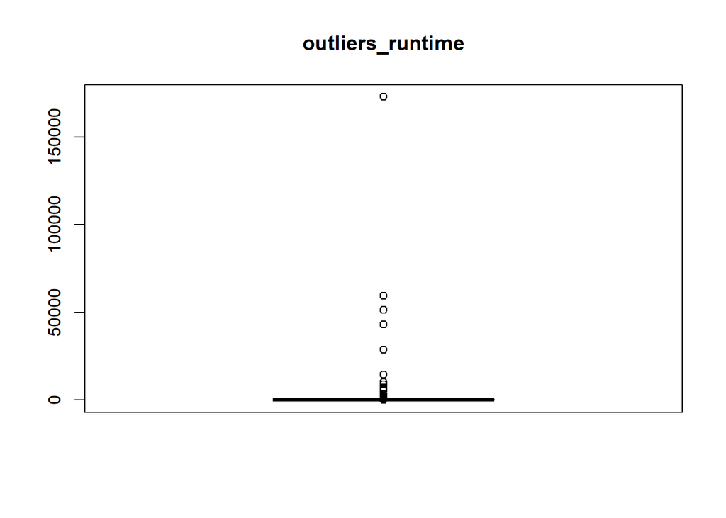

```r
# boxplot for outliers
boxplot(merged_data$runtimeMinutes, main = "outliers_runtime")
```

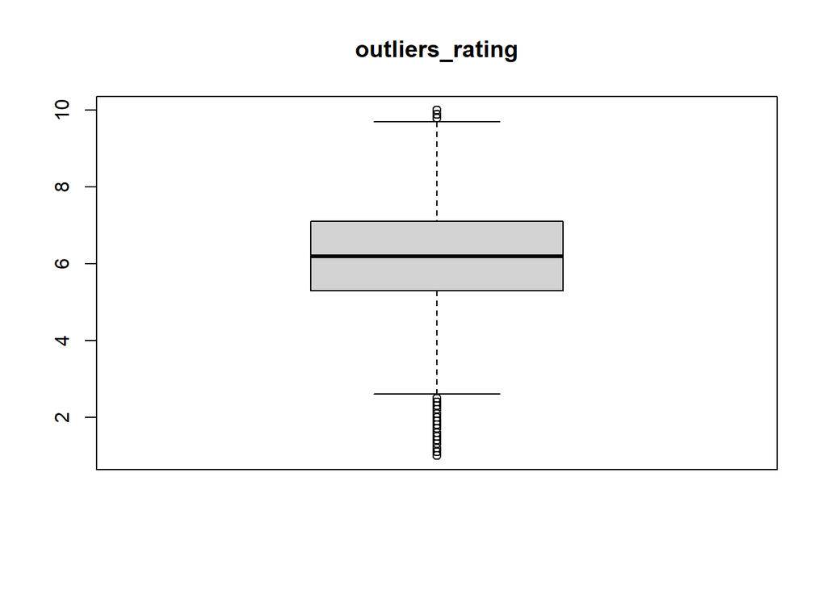

```r
boxplot(merged_data$averageRating, main = "outliers_rating")
```

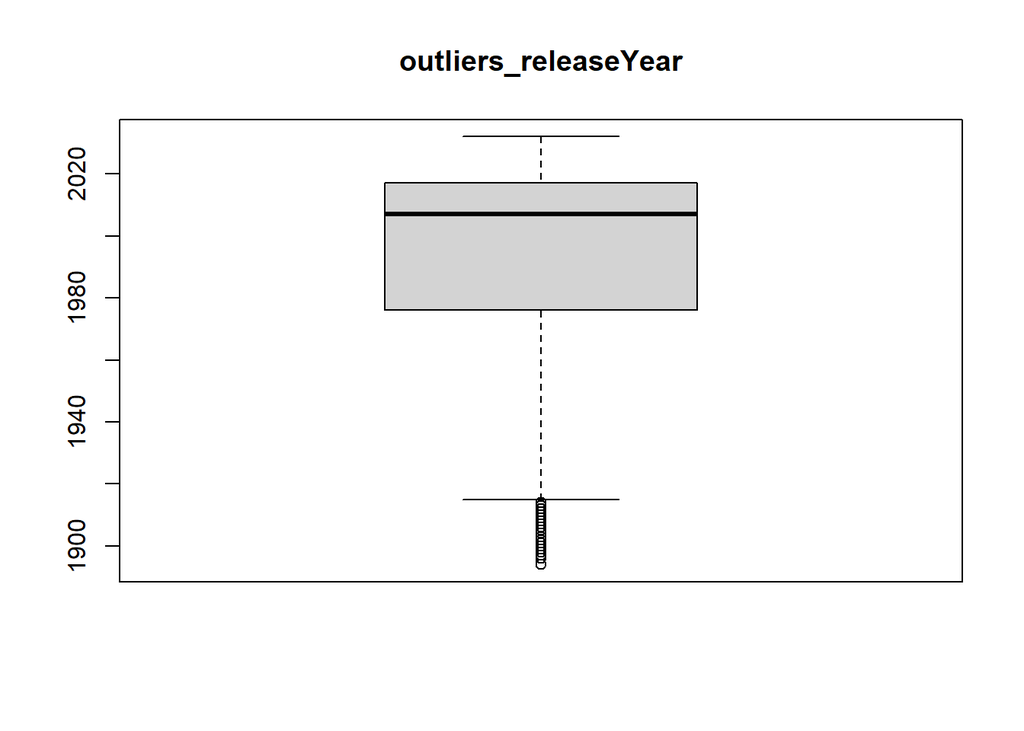

```r
boxplot(merged_data$startYear, main = "outliers_releaseYear")
```

```r
# remove NA
NA_removed <- merged_data%>% filter(!is.na(runtimeMinutes) & !is.na(averageRating) & !is.na(startYear))

#summarise variables

# summary of runtimeMinutes
mean(NA_removed$runtimeMinutes, na.rm = TRUE)
```

```
## [1] 94.54284
```

```r
max(NA_removed$runtimeMinutes, na.rm = TRUE)
```

```
## [1] 59460
```

```r
min(NA_removed$runtimeMinutes, na.rm = TRUE)
```

```
## [1] 1
```

```r
# summary of averageRating
mean(NA_removed$averageRating, na.rm = TRUE)
```

```
## [1] 6.139796
```

```r
max(NA_removed$averageRating, na.rm = TRUE)
```

```
## [1] 10
```

```r
min(NA_removed$averageRating, na.rm = TRUE)
```

```
## [1] 1
```

```r
# summary of release year
mean(NA_removed$startYear, na.rm = TRUE)
```

```
## [1] 1996.691
```

```r
max(NA_removed$startYear, na.rm = TRUE)
```

```
## [1] 2025
```

```r
min(NA_removed$startYear, na.rm = TRUE)
```

```
## [1] 1894
```

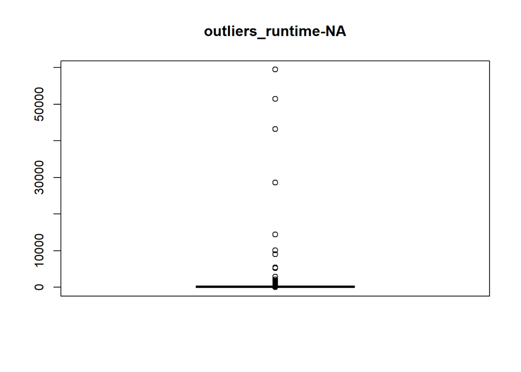

```r
# boxplot for outliers
boxplot(NA_removed$runtimeMinutes, main = "outliers_runtime-NA")
```

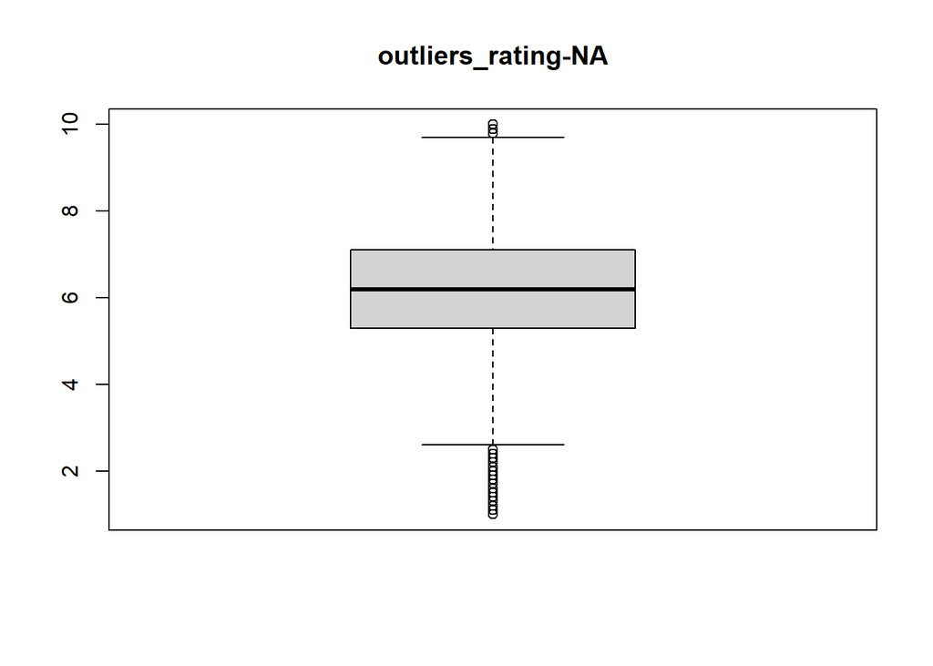

```r
boxplot(NA_removed$averageRating, main = "outliers_rating-NA")
```

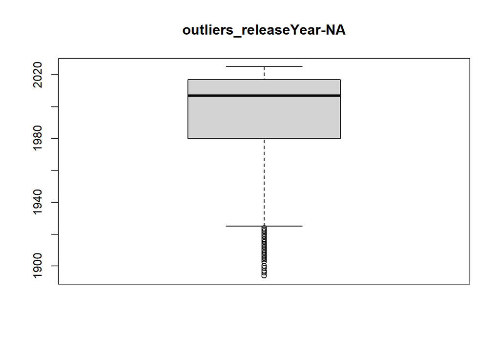

```r
boxplot(NA_removed$startYear, main = "outliers_releaseYear-NA")
```

Link to GitHub repository https://github.com/mvaneijl/group3_dprep2025.git